# Trabajo_Practico 2

Ana Vargas Frutos

Septiembre, 2023

### Trabajo Práctico 2 - Instrumentos de análisis de datos II

```r
library(tidyverse)
library(lubridate)
library(ggmap)
library(sf)
```

```r
library(ggplot2)
library(skimr)
```

Este trabajo analiza la disponibilidad de estaciones de bicicletas públicas en la ciudad de Paris, para lo cual utiliza la base de datos del sistema Velib y la capa de distritos de la ciudad. La información contenida permitirá localizar cuál es el distrito de la ciudad de París con mayor disponbilidad de estaciones de bicicletas.

**1) Crear un repositorio público en la cuenta personal de Github para el TP2**

**2) Crear un proyecto en la computadora desde RStudio y vincular al repositorio de Github**

**3) Crear un script.R / Rmarkdown guardarlo en el proyecto**

Se carga la base de datos y se explora la base de datos:

```r
dispon_velib_Paris <- read.csv2("velib-disponibilite-en-temps-reel.csv", sep = ";",  header =TRUE)
```

```r
dim(dispon_velib_Paris)
```

```
## [1] 1473   14
```

```r
head(dispon_velib_Paris)
```

```
##   Identifiant.station                   Nom.station Station.en.fonctionnement
## 1               44015    Rouget de L'isle - Watteau                       OUI
## 2               16107 Benjamin Godard - Victor Hugo                       OUI
## 3                9020            Toudouze - Clauzel                       OUI
## 4               31104     Mairie de Rosny-sous-Bois                       OUI
## 5               12109               Mairie du 12ème                       OUI
## 6               32017                     Basilique                       OUI
##   Capacité.de.la.station Nombre.bornettes.libres Nombre.total.vélos.disponibles
## 1                     20                       1                             18
## 2                     35                      29                              6
## 3                     21                      21                              0
## 4                     30                      11                             16
## 5                     30                       4                             23
## 6                     22                       7                             13
##   Vélos.mécaniques.disponibles Vélos.électriques.disponibles
```

[output cut: 27 more lines]

```r
tail(dispon_velib_Paris)
```

```
##      Identifiant.station                           Nom.station
## 1468               42004 Westermeyer - Paul Vaillant-Couturier
## 1469                9104                  Caumartin - Provence
## 1470                8004   Malesherbes - Place de la Madeleine
## 1471                4104                Sebastopol - Rambuteau
## 1472               18026                    Ruisseau - Ordener
## 1473               18024                Clignancourt - Ordener
##      Station.en.fonctionnement Capacité.de.la.station Nombre.bornettes.libres
## 1468                       OUI                     25                       1
## 1469                       OUI                     22                      21
## 1470                       OUI                     67                      60
## 1471                       OUI                     16                      14
## 1472                       OUI                     35                      21
## 1473                       OUI                     35                      20
##      Nombre.total.vélos.disponibles Vélos.mécaniques.disponibles
```

[output cut: 34 more lines]

```r
str(dispon_velib_Paris)
```

```
## 'data.frame':    1473 obs. of  14 variables:
##  $ Identifiant.station           : int  44015 16107 9020 31104 12109 32017 14111 11104 14014 8026 ...
##  $ Nom.station                   : chr  "Rouget de L'isle - Watteau" "Benjamin Godard - Victor Hugo" "Toudouze - Clauzel" "Mairie de Rosny-sous-Bois" ...
##  $ Station.en.fonctionnement     : chr  "OUI" "OUI" "OUI" "OUI" ...
##  $ Capacité.de.la.station        : int  20 35 21 30 30 22 25 20 60 12 ...
##  $ Nombre.bornettes.libres       : int  1 29 21 11 4 7 23 6 46 5 ...
##  $ Nombre.total.vélos.disponibles: int  18 6 0 16 23 13 1 13 13 6 ...
##  $ Vélos.mécaniques.disponibles  : int  11 5 0 10 22 8 1 7 7 6 ...
##  $ Vélos.électriques.disponibles : int  7 1 0 6 1 5 0 6 6 0 ...
##  $ Borne.de.paiement.disponible  : chr  "OUI" "OUI" "OUI" "OUI" ...
##  $ Retour.vélib.possible         : chr  "OUI" "OUI" "OUI" "OUI" ...
##  $ Actualisation.de.la.donnée    : chr  "2023-10-08T17:20:49-03:00" "2023-10-08T17:15:24-03:00" "2023-10-08T17:20:14-03:00" "2023-10-08T17:17:48-03:00" ...
##  $ Coordonnées.géographiques     : chr  "48.778192750803, 2.3963020229163" "48.865983, 2.275725" "48.87929591733507, 2.3373600840568547" "48.871256519012, 2.4865807592869" ...
##  $ Nom.communes.équipées         : chr  "Vitry-sur-Seine" "Paris" "Paris" "Rosny-sous-Bois" ...
##  $ Code.INSEE.communes.équipées  : logi  NA NA NA NA NA NA ...
```

```r
summary(dispon_velib_Paris)
```

```
##  Identifiant.station Nom.station        Station.en.fonctionnement
##  Min.   : 1001       Length:1473        Length:1473
##  1st Qu.:11031       Class :character   Class :character
##  Median :16116       Mode  :character   Mode  :character
##  Mean   :18638
##  3rd Qu.:22002
##  Max.   :92008
##  Capacité.de.la.station Nombre.bornettes.libres Nombre.total.vélos.disponibles
##  Min.   :  0.00         Min.   :  0.0           Min.   : 0.00
##  1st Qu.: 23.00         1st Qu.: 12.0           1st Qu.: 3.00
##  Median : 29.00         Median : 19.0           Median : 7.00
##  Mean   : 31.38         Mean   : 21.4           Mean   : 8.93
##  3rd Qu.: 37.00         3rd Qu.: 28.0           3rd Qu.:13.00
##  Max.   :200.00         Max.   :200.0           Max.   :45.00
##  Vélos.mécaniques.disponibles Vélos.électriques.disponibles
##  Min.   : 0.000               Min.   : 0.000
##  1st Qu.: 1.000               1st Qu.: 1.000
##  Median : 3.000               Median : 2.000
##  Mean   : 5.845               Mean   : 3.085
##  3rd Qu.: 9.000               3rd Qu.: 4.000
##  Max.   :40.000               Max.   :26.000
##  Borne.de.paiement.disponible Retour.vélib.possible Actualisation.de.la.donnée
##  Length:1473                  Length:1473           Length:1473
##  Class :character             Class :character      Class :character
##  Mode  :character             Mode  :character      Mode  :character
##
##
##
##  Coordonnées.géographiques Nom.communes.équipées Code.INSEE.communes.équipées
##  Length:1473               Length:1473           Mode:logical
##  Class :character          Class :character      NA's:1473
##  Mode  :character          Mode  :character
##
##
##
```

Esta base de datos consiste en el registro de la disponbilidad de bicicletas en Paris y en las afueras de la ciudad, conteniendo datos de las estaciones, su ubicación, capacidad de la estación, disponibilidad de diferentes tipos de bicicletas según un registro horario y datos geográficos.

Se ordena la base de datos de la siguietne manera:

```r
dispon_velib_Paris2 <- dispon_velib_Paris %>%
  rename(IDStat = Identifiant.station,
         NameStat = Nom.station,
         Capacity = Capacité.de.la.station,
         Num_Free_Doc= Nombre.bornettes.libres,
         Num_BikeTotal = Nombre.total.vélos.disponibles,
         Num_EBike= Vélos.électriques.disponibles,
         Num_Bike= Vélos.mécaniques.disponibles,
         Date=Actualisation.de.la.donnée,
         Name_Com = Nom.communes.équipées,
         GeoCoordinates = Coordonnées.géographiques)
```

Se modifican los datos de fecha y hora de registros:

```r
dispon_velib_Paris2<- dispon_velib_Paris2%>%
  mutate(Date=ymd_hms(Date))
```

```r
dispon_velib_Paris2 <- dispon_velib_Paris2 %>%
  mutate(month=month(Date, label=TRUE),
         year=year(Date),
         day=wday(Date, label=TRUE, abbr=FALSE),
         hour=hour(Date))
```

Al distinguir por año y mes, podemos observar la distribución de los registros, de la siguiente manera:

```r
unique(dispon_velib_Paris2$month)
```

```
##  [1] Oct Sep Jul May Jun Jan Aug Dec Feb Mar Apr
## 12 Levels: Jan < Feb < Mar < Apr < May < Jun < Jul < Aug < Sep < ... < Dec
```

```r
(tabla_mont <- dispon_velib_Paris2$month%>%
  table())
```

```
## .
##  Jan  Feb  Mar  Apr  May  Jun  Jul  Aug  Sep  Oct  Nov  Dec
##    3    1    1    2    2    3   11    5    6 1437    0    2
```

```r
(tabla_mont <- dispon_velib_Paris2$year%>%
  table())
```

```
## .
## 2018 2019 2020 2021 2022 2023
##    3    1    1    3    4 1461
```

Los datos más relevantes son los del 2023, por lo que filtraremos esos datos:

```r
dispon_velib_Paris_23 <- dispon_velib_Paris2 %>%
  filter(year==2023) %>%
  mutate(time_day=case_when(
    hour>=as.numeric(6) ~ "morning",
    hour>=as.numeric(13) ~ "afternoon",
    hour>=as.numeric(20) ~ "night",
    TRUE ~ "latenight"))
```

A fin de lograr curzar los datos del registro con lso datos espaciales, convertimos la tabla en una base de datos espacial. Para ello, obtenemos los datos de las coordenadas y la transformamos la nueva base:

```r
dispon_velib_Paris_23_geo <- dispon_velib_Paris_23 %>%
  mutate(GeoCoordinates = strsplit(GeoCoordinates, ", ")) %>%   # Split the coordinates
  mutate(longitude = as.numeric(sapply(GeoCoordinates, `[`, 2)), # Extract longitud
         latitude = as.numeric(sapply(GeoCoordinates, `[`, 1))) %>%  # Extract latitude
  st_as_sf(coords = c("longitude", "latitude"), crs = 4326)  # Create an sf object
```

```r
dispon_velib_Paris_23_geo
```

```
## Simple feature collection with 1461 features and 19 fields
## Geometry type: POINT
## Dimension:     XY
## Bounding box:  xmin: 2.165597 ymin: 48.76462 xmax: 2.538242 ymax: 48.95143
## Geodetic CRS:  WGS 84
## First 10 features:
##    IDStat                            NameStat Station.en.fonctionnement
## 1   44015          Rouget de L'isle - Watteau                       OUI
## 2   16107       Benjamin Godard - Victor Hugo                       OUI
## 3    9020                  Toudouze - Clauzel                       OUI
## 4   31104           Mairie de Rosny-sous-Bois                       OUI
## 5   12109                     Mairie du 12ème                       OUI
## 6   32017                           Basilique                       OUI
## 7   14111         Cassini - Denfert-Rochereau                       OUI
## 8   11104 Charonne - Robert et Sonia Delaunay                       OUI
```

[output cut: 57 more lines]

**4. Visualización**

Descargamos los datos de los distritos:

```r
distritos_Paris <- st_read("arrondissements/arrondissements.shp",
                        stringsAsFactors = TRUE)
```

Podemos observar que ambas bases de datos espaciales trabajan con el mismo codigo CRS, por lo que no se requerirá cambios de proyecciones.

Continuamos explorando la base de datos de Distritos:

```r
summary(distritos_Paris)
```

```
##       n_sq_ar        c_ar      c_arinsee          l_ar
##  750000001: 1   1      : 1   75101  : 1   10ème Ardt: 1
##  750000002: 1   10     : 1   75102  : 1   11ème Ardt: 1
##  750000003: 1   11     : 1   75103  : 1   12ème Ardt: 1
##  750000004: 1   12     : 1   75104  : 1   13ème Ardt: 1
##  750000005: 1   13     : 1   75105  : 1   14ème Ardt: 1
##  750000006: 1   14     : 1   75106  : 1   15ème Ardt: 1
##  (Other)  :14   (Other):14   (Other):14   (Other)   :14
##                 l_aroff        n_sq_co      surface           perimetre
##  Batignolles-Monceau: 1   750001537:20   Min.   :  991154   Min.   : 4519
##  Bourse             : 1                  1st Qu.: 2172001   1st Qu.: 6413
##  Buttes-Chaumont    : 1                  Median : 3985047   Median : 8191
##  Buttes-Montmartre  : 1                  Mean   : 5268639   Mean   : 9522
##  Élysée             : 1                  3rd Qu.: 6195201   3rd Qu.:10895
##  Entrepôt           : 1                  Max.   :16372542   Max.   :24090
##  (Other)            :14
##           geometry
##  POLYGON      :20
##  epsg:4326    : 0
##  +proj=long...: 0
##
##
##
##
```

```r
dim(distritos_Paris)
```

```
## [1] 20  9
```

Esta base de datos cuenta con 20 observaciones correspondiente a los 20 distritos de la ciudad de París. Contiene, ademås, los datos geográficos, la superficie, el perímetro y los códigos de los distritos.

Exploramos la relación entre ambas bases de datos:

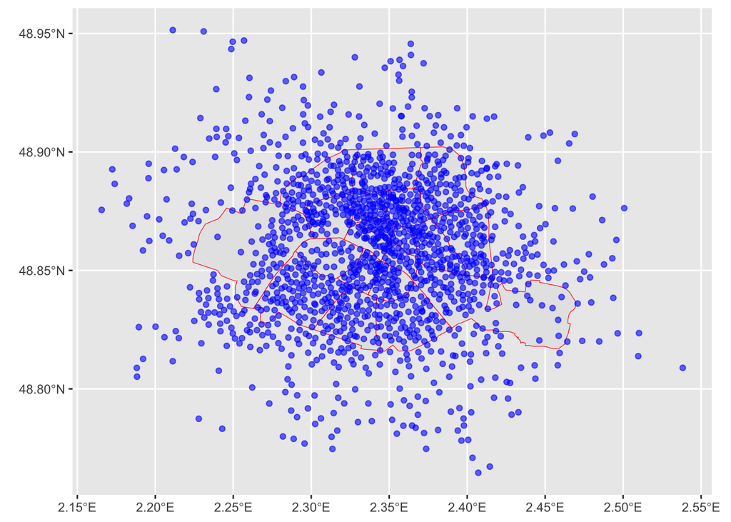

```r
ggplot()+
  geom_sf(data=distritos_Paris, colour= "red", size=1)+
  geom_sf(data=dispon_velib_Paris_23_geo, color="blue", alpha=0.6)
```

Como existen más datos de los necesarios así que cruzamos ambas bases de datos para filtrar espacialemente los datos que se encuentran dentro de Paris:

```r
dispon_velib_Paris_23_geo2 <- st_filter(dispon_velib_Paris_23_geo, distritos_Paris)
```

Verificamos el resultado:

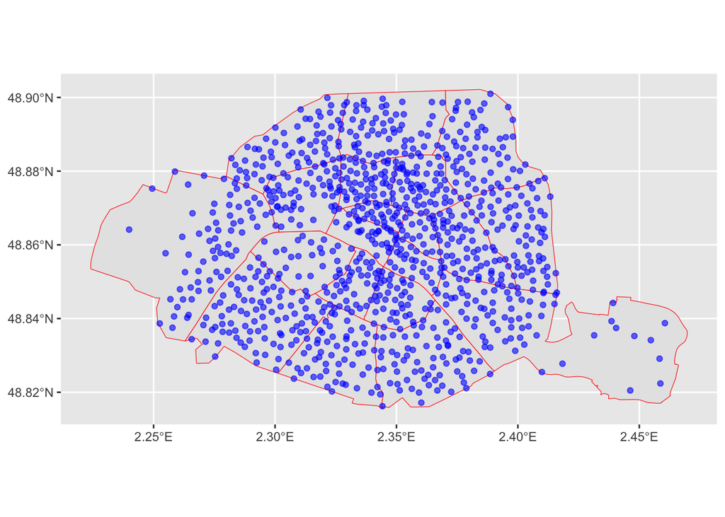

```r
ggplot()+
  geom_sf(data=distritos_Paris, colour= "red", size=1)+
  geom_sf(data=dispon_velib_Paris_23_geo2, color="blue", alpha=0.6)
```

Unimos ambas bases y realizamos los cálculos para las visualizaciones:

```r
dispon_velib_distrito<- st_join(dispon_velib_Paris_23_geo2,distritos_Paris)
```

```r
dispon_velib_distrito2<- dispon_velib_distrito %>%
  group_by(l_ar) %>%
  summarise(Cantidad=n())
```

```r
dispon_velib_distrito2 <- dispon_velib_distrito2 %>%
  st_drop_geometry()
```

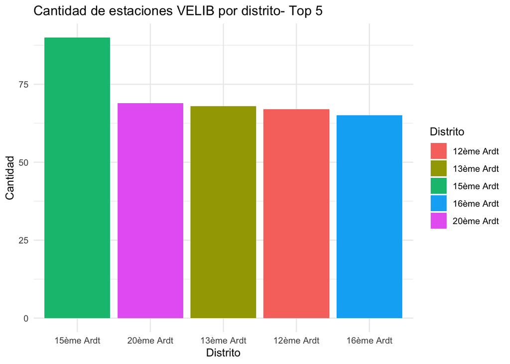

```r
ggplot()+
  geom_bar(data=dispon_velib_distrito2 %>%
             top_n(5,Cantidad), aes(x=reorder(l_ar, -Cantidad), weight=Cantidad, fill=l_ar))+
  labs(title="Cantidad de estaciones VELIB por distrito- Top 5",
       x="Distrito",
       y="Cantidad",
       fill = "Distrito")+
  theme_minimal()
```

Observamos que el Distrito 15 es el que cuenta con mayor cantidad de estaciones Velib, seguido por el Distrito 20, 13, 12 y 16.

Para una mejor localización de la distribución de las estaciones, utilizamos el mapa de distritos al cual agregamos el cálculo de las cantidades de estaciones por distrito.

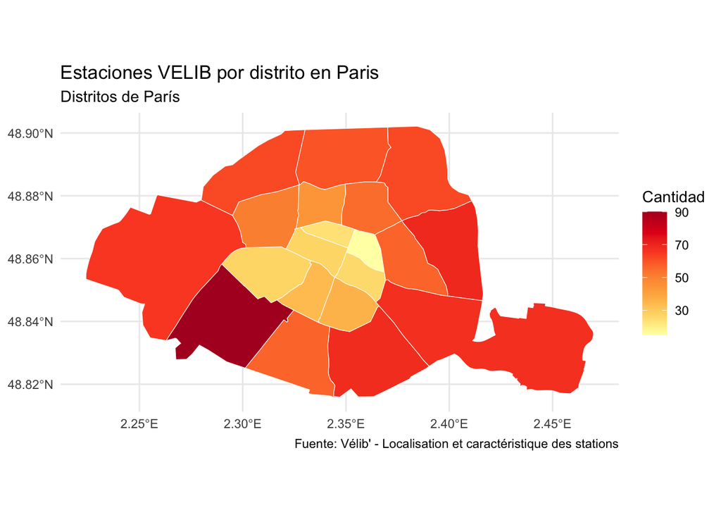

```r
ggplot(distritos_Paris %>%
  left_join(dispon_velib_distrito2) )+
  geom_sf(aes(fill=Cantidad), color="white")+
    labs(title = "Estaciones VELIB por distrito en Paris",
         subtitle = "Distritos de París",
         fill = "Cantidad",
         caption= "Fuente: Vélib' - Localisation et caractéristique des stations") +
  scale_fill_distiller(palette = "YlOrRd", direction = 1) +
  theme_minimal()
```

Este mapa nos permite observar que aquellos distritos medianamente alejados del centro de la ciudad son los que cuentan con mayor cantida de estaciones.

**5. Al finalizar, guardar el script.R / rmarkdown.Rmd y subir los cambios en el proyecto *local* al repositorio *remoto* de Github**

- Recordar la secuencia (por terminal o por la pestaña *GIT* del panel de control de Rstudio):
  - `git pull`
  - `git add -A`
  - `git commit -m "acá el mensaje"`
  - `git push`

**6. Entrega: Una vez realizado los puntos anteriores, copiar el link del repositorio en la columna TP 2: (https://docs.google.com/spreadsheets/d/1zs4iAFX6D0qZTse62nVPRreOXxhb17DaPr2H5Qzc1is/edit#gid=0).**